# Customer Satisfaction

```python
import numpy as np # linear algebra
import pandas as pd # data processing, CSV file I/O (e.g. pd.read_csv)
import matplotlib.pyplot as plt
import seaborn as sns
#import plotly.express as px
import warnings
warnings.filterwarnings('ignore')

df = pd.read_csv(r"D:\data\airline\train.csv")
sns.set_palette('Paired')
```

```python
df.info()
```

```
<class 'pandas.core.frame.DataFrame'>
RangeIndex: 103904 entries, 0 to 103903
Data columns (total 25 columns):
 #   Column                             Non-Null Count   Dtype
---  ------                             --------------   -----
 0   Unnamed: 0                         103904 non-null  int64
 1   id                                 103904 non-null  int64
 2   Gender                             103904 non-null  object
 3   Customer Type                      103904 non-null  object
 4   Age                                103904 non-null  int64
 5   Type of Travel                     103904 non-null  object
 6   Class                              103904 non-null  object
 7   Flight Distance                    103904 non-null  int64
 8   Inflight wifi service              103904 non-null  int64
 9   Departure/Arrival time convenient  103904 non-null  int64
```

[output cut: 17 more lines]

```python
#df.drop_duplicates()
#df
```

```python
#Unnamed is a repeat of the index

#df=df.drop(columns="Unnamed: 0")
#df
```

convert categorical to numerical data

```python
df= pd.concat([df,pd.get_dummies(df['satisfaction'])],axis=1)
df= pd.concat([df,pd.get_dummies(df['Class'])],axis=1)
df= pd.concat([df,pd.get_dummies(df['Customer Type'])],axis=1)
```

getting central tendency of the dataframe

```python
df.describe()
```

|  | Unnamed: 0 | id | Age | Flight Distance | Inflight wifi service | Departure/Arrival time convenient | Ease of Online booking | Gate location | Food and drink | Online boarding | Seat comfort | Inflight entertainment | On-board service | Leg room service | Baggage handling | Checkin service | Inflight service | Cleanliness | Departure Delay in Minutes | Arrival Delay in Minutes |
| --- | --- | --- | --- | --- | --- | --- | --- | --- | --- | --- | --- | --- | --- | --- | --- | --- | --- | --- | --- | --- |
| count | 103904.000000 | 103904.000000 | 103904.000000 | 103904.000000 | 103904.000000 | 103904.000000 | 103904.000000 | 103904.000000 | 103904.000000 | 103904.000000 | 103904.000000 | 103904.000000 | 103904.000000 | 103904.000000 | 103904.000000 | 103904.000000 | 103904.000000 | 103904.000000 | 103904.000000 | 103594.000000 |
| mean | 51951.500000 | 64924.210502 | 39.379706 | 1189.448375 | 2.729683 | 3.060296 | 2.756901 | 2.976883 | 3.202129 | 3.250375 | 3.439396 | 3.358158 | 3.382363 | 3.351055 | 3.631833 | 3.304290 | 3.640428 | 3.286351 | 14.815618 | 15.178678 |
| std | 29994.645522 | 37463.812252 | 15.114964 | 997.147281 | 1.327829 | 1.525075 | 1.398929 | 1.277621 | 1.329533 | 1.349509 | 1.319088 | 1.332991 | 1.288354 | 1.315605 | 1.180903 | 1.265396 | 1.175663 | 1.312273 | 38.230901 | 38.698682 |
| min | 0.000000 | 1.000000 | 7.000000 | 31.000000 | 0.000000 | 0.000000 | 0.000000 | 0.000000 | 0.000000 | 0.000000 | 0.000000 | 0.000000 | 0.000000 | 0.000000 | 1.000000 | 0.000000 | 0.000000 | 0.000000 | 0.000000 | 0.000000 |
| 25% | 25975.750000 | 32533.750000 | 27.000000 | 414.000000 | 2.000000 | 2.000000 | 2.000000 | 2.000000 | 2.000000 | 2.000000 | 2.000000 | 2.000000 | 2.000000 | 2.000000 | 3.000000 | 3.000000 | 3.000000 | 2.000000 | 0.000000 | 0.000000 |
| 50% | 51951.500000 | 64856.500000 | 40.000000 | 843.000000 | 3.000000 | 3.000000 | 3.000000 | 3.000000 | 3.000000 | 3.000000 | 4.000000 | 4.000000 | 4.000000 | 4.000000 | 4.000000 | 3.000000 | 4.000000 | 3.000000 | 0.000000 | 0.000000 |
| 75% | 77927.250000 | 97368.250000 | 51.000000 | 1743.000000 | 4.000000 | 4.000000 | 4.000000 | 4.000000 | 4.000000 | 4.000000 | 5.000000 | 4.000000 | 4.000000 | 4.000000 | 5.000000 | 4.000000 | 5.000000 | 4.000000 | 12.000000 | 13.000000 |
| max | 103903.000000 | 129880.000000 | 85.000000 | 4983.000000 | 5.000000 | 5.000000 | 5.000000 | 5.000000 | 5.000000 | 5.000000 | 5.000000 | 5.000000 | 5.000000 | 5.000000 | 5.000000 | 5.000000 | 5.000000 | 5.000000 | 1592.000000 | 1584.000000 |

```python
df.columns
```

```
Index(['Unnamed: 0', 'id', 'Gender', 'Customer Type', 'Age', 'Type of Travel',
       'Class', 'Flight Distance', 'Inflight wifi service',
       'Departure/Arrival time convenient', 'Ease of Online booking',
       'Gate location', 'Food and drink', 'Online boarding', 'Seat comfort',
       'Inflight entertainment', 'On-board service', 'Leg room service',
       'Baggage handling', 'Checkin service', 'Inflight service',
       'Cleanliness', 'Departure Delay in Minutes', 'Arrival Delay in Minutes',
       'satisfaction', 'neutral or dissatisfied', 'satisfied', 'Business',
       'Eco', 'Eco Plus', 'Loyal Customer', 'disloyal Customer'],
      dtype='object')
```

separate categorical and numerical data into two different dataframes

```python
df_cat=df[['Gender', 'Customer Type', 'Type of Travel', 'Class', 'satisfaction' ]]
df_num=df[['Age', 'Flight Distance', 'Inflight wifi service', 'Departure/Arrival time convenient', 'Ease of Online booking',
       'Gate location', 'Food and drink', 'Online boarding', 'Seat comfort',
       'Inflight entertainment', 'On-board service', 'Leg room service',
       'Baggage handling', 'Checkin service', 'Inflight service',
       'Cleanliness', 'Departure Delay in Minutes',
        'Arrival Delay in Minutes',
        'neutral or dissatisfied', 'satisfied', 'Business','Eco', 'Eco Plus', 'Loyal Customer', 'disloyal Customer']]
```

exploration of the sample demographics and satisfaction of each subgroup

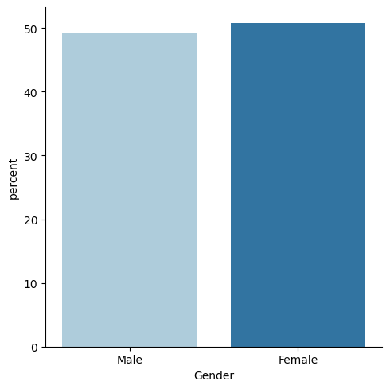

```python
plt.figure(figsize=(8,4))
sns.catplot( data=df, x="Gender", kind='count', palette= 'Paired',stat='percent')
```

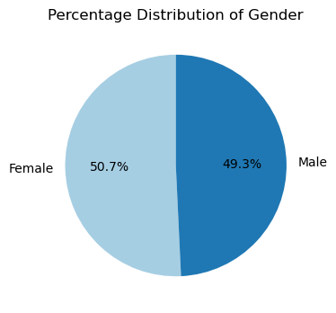

```python
Gender_count=df['Gender'].value_counts()
slices=Gender_count.values
plt.figure(figsize=(8,4))
plt.pie(slices, labels=['Female','Male'], autopct='%1.1f%%', startangle=90)
plt.title('Percentage Distribution of Gender')
```

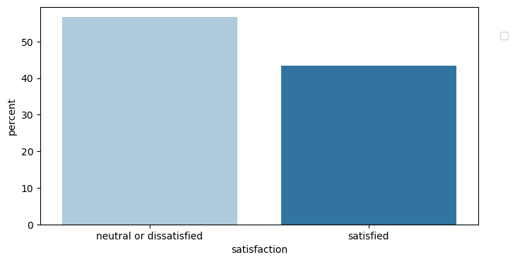

```python
plt.figure(figsize=(8,4))
sns.countplot(data=df,x='satisfaction', hue ='satisfaction', palette= 'Paired', stat='percent')
plt.legend(loc=(1.05,.85))
```

[figure not shown]

```python
slices_satisfaction=df['satisfaction'].value_counts()
labels_satisfaction=slices_satisfaction.index
plt.figure(figsize=(8,4))
plt.pie(slices, labels=labels_satisfaction, autopct='%1.1f%%', startangle=90)
plt.title('Percentage Distribution of satisfaction')
```

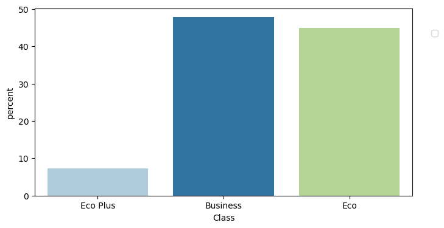

```python
plt.figure(figsize=(8,4))
sns.countplot(data=df,x='Class', palette= 'Paired', stat='percent')
plt.legend(loc=(1.05,.85))
```

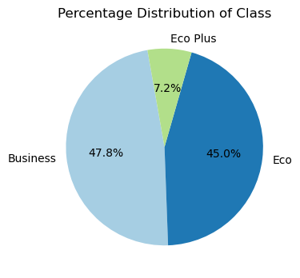

```python
Class_count=df['Class'].value_counts()
labels_class=Class_count.index
slices_class=Class_count.values

plt.figure(figsize=(8,4))
plt.pie(slices_class, labels=labels_class, autopct='%1.1f%%', startangle=100)
plt.title('Percentage Distribution of Class')
```

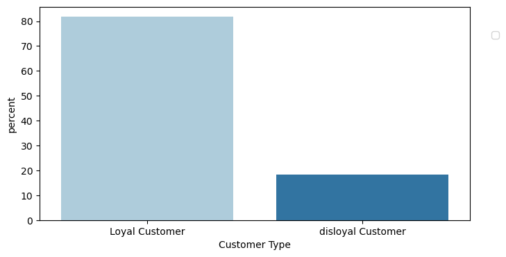

```python
plt.figure(figsize=(8,4))
sns.countplot(data=df,x='Customer Type', palette= 'Paired', stat='percent')
plt.legend(loc=(1.05,.85))
```

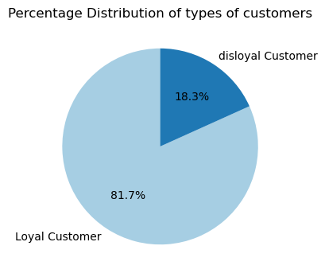

```python
slices_type=df['Customer Type'].value_counts()
labels_type=slices_type.index
plt.figure(figsize=(8,4))
plt.pie(slices_type, labels=labels_type, autopct='%1.1f%%', startangle=90)
plt.title('Percentage Distribution of types of customers')
```

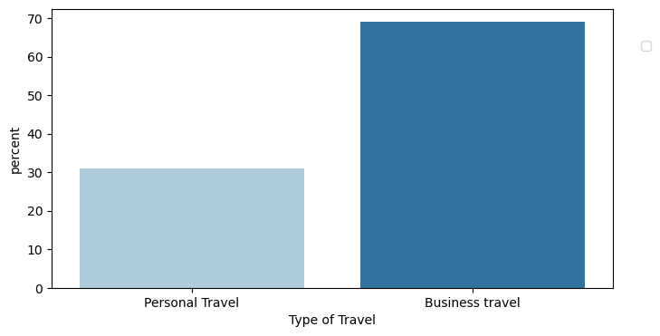

```python
plt.figure(figsize=(8,4))
sns.countplot(data=df,x='Type of Travel', palette= 'Paired', stat='percent')
plt.legend(loc=(1.05,.85))
```

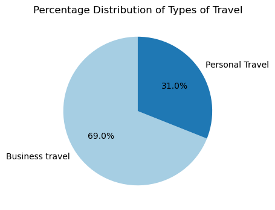

```python
slices_travel=df['Type of Travel'].value_counts()
labels_travel=slices_travel.index
plt.figure(figsize=(8,4))
plt.pie(slices_travel, labels=labels_travel, autopct='%1.1f%%', startangle=90)
plt.title('Percentage Distribution of Types of Travel')
```

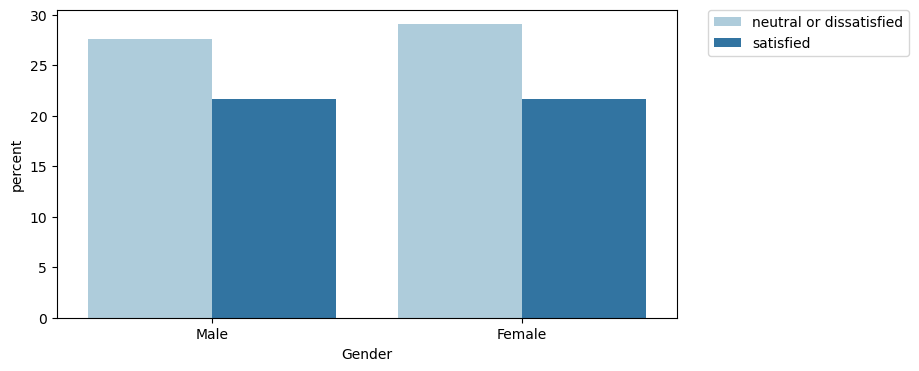

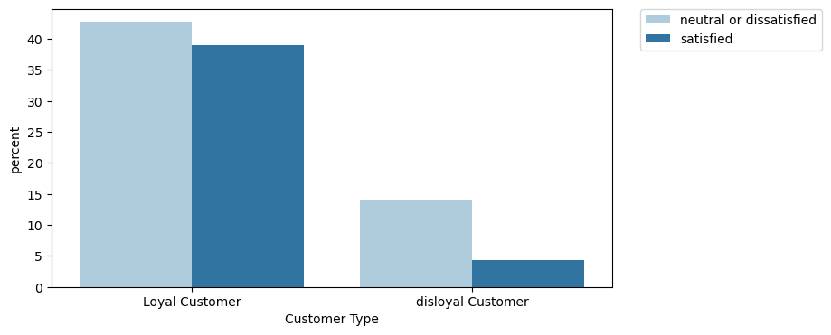

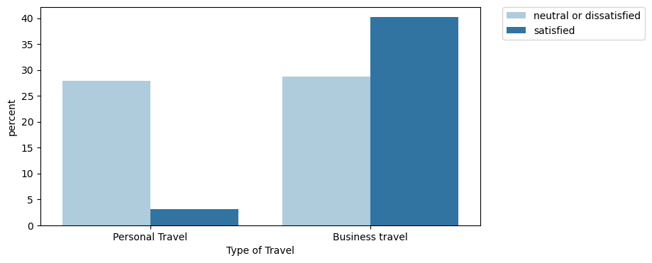

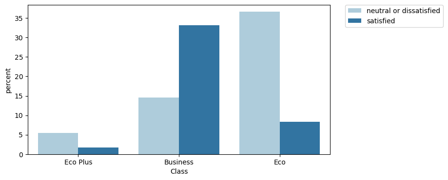

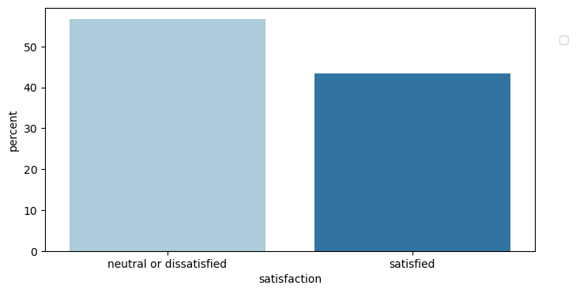

```python
for i in df_cat:
    plt.figure(figsize=(8,4))
    sns.countplot(data=df,x=i,hue ='satisfaction', palette= 'Paired', stat='percent')
    plt.legend(loc=(1.05,.85))
```

```python
#percentage of the business class that reports feeling satisfied
len(df[(df['satisfaction']=='satisfied') & (df['Class']=='Business')])*100/len(df[df['Class']=='Business'])
```

```
69.42514849491593
```

```python
#percentage of the economy class that reports feeling satisfied
len(df[(df['satisfaction']=='satisfied') & (df['Class']=='Eco')])*100/len(df[df['Class']=='Eco'])
```

```
18.61375548186972
```

```python
#percentage of the Economy Plus class that reports feeling satisfied
len(df[(df['satisfaction']=='satisfied') & (df['Class']=='Eco Plus')])*100/len(df[df['Class']=='Eco Plus'])
```

```
24.60635174806512
```

```python
#overall satisfaction
len(df[df['satisfaction']=='satisfied'])*100/len(df)
```

```
43.333269171542966
```

Male and Female Customers are equally satisfied. There are more Loyal Customers than disloyal ones, and the loyal ones are more satisfied, however both groups are more neutral or dissatisfied than satisfied. More customers travel for business and they are more satisfied than the ones who travel for personal reasons. Most of the Customers travel Business and Economy class, but customers who chose Business are a lot more satisfied.

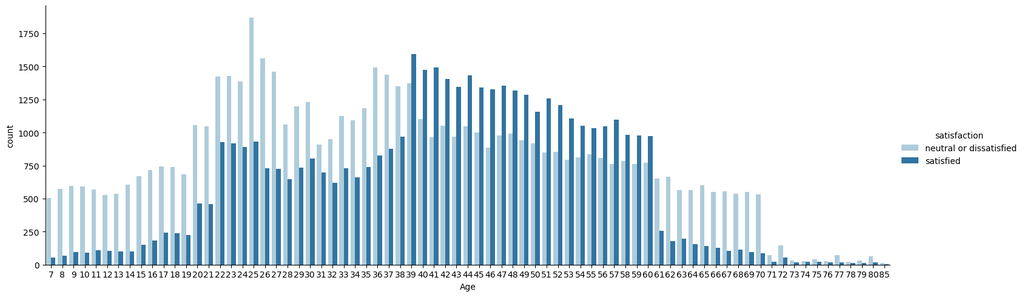

```python
sns.catplot( data=df, x="Age", aspect=3.0, kind='count', hue='satisfaction', palette= 'Paired')
```

Passengers under 39 and passengers over 60 tend to be more dissatisfied or neutral than satisfied, however this could be because the passenger between ages 39 to 60 travel more in business class than customers of other ages

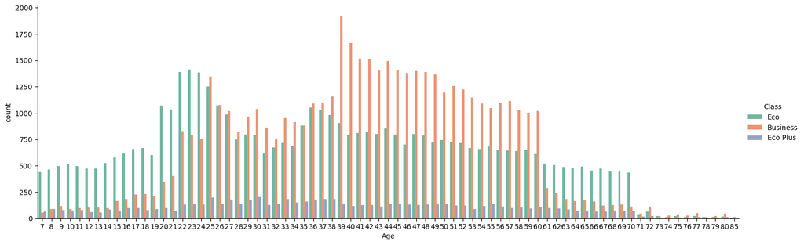

```python
sns.catplot( data=df, x="Age", aspect=3.0, kind='count', hue='Class', palette= 'Set2')
```

the ranges of ages that report satisfaction overlap with the passengers who travel in business class

```python
How did passengers answered the survey along the 3 classes?
```

[output not shown]

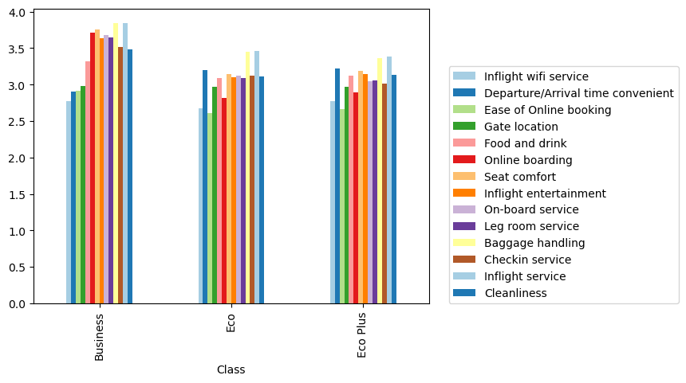

```python
df.groupby('Class')[['Inflight wifi service',
       'Departure/Arrival time convenient', 'Ease of Online booking',
       'Gate location', 'Food and drink', 'Online boarding', 'Seat comfort',
       'Inflight entertainment', 'On-board service', 'Leg room service',
       'Baggage handling', 'Checkin service', 'Inflight service',
       'Cleanliness']].mean().plot(kind='bar')
plt.legend(loc=(1.05,0))
```

Online boarding has the greatest difference in average rating from the economy class and the business class. Is the process different? Business class passengers also rate seat comfort higher. This is an expected difference given that Business class seats are bigger in general.

Where are the biggest differences?

```python
df_num[df['Class']=='Business'].mean()-df_num[df['Class']=='Eco'].mean()
```

```
Age                                   4.41
Flight Distance                     932.54
Inflight wifi service                 0.10
Departure/Arrival time convenient    -0.29
Ease of Online booking                0.31
Gate location                         0.01
Food and drink                        0.24
Online boarding                       0.90
Seat comfort                          0.62
Inflight entertainment                0.54
On-board service                      0.56
Leg room service                      0.56
Baggage handling                      0.39
Checkin service                       0.40
Inflight service                      0.38
Cleanliness                           0.37
Departure Delay in Minutes           -0.76
Arrival Delay in Minutes             -1.09
neutral or dissatisfied              -0.51
satisfied                             0.51
Business                              1.00
Eco                                  -1.00
Eco Plus                              0.00
Loyal Customer                        0.09
disloyal Customer                    -0.09
dtype: float64
```

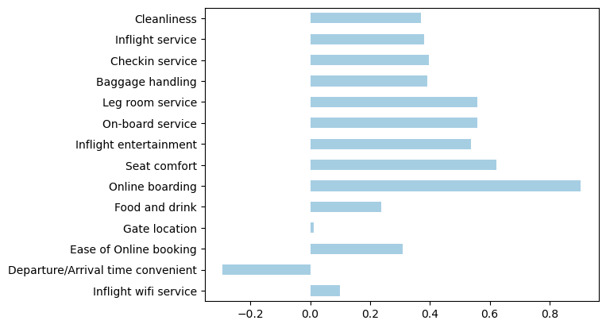

```python
dif=df_num[df['Class']=='Business'].mean()-df_num[df['Class']=='Eco'].mean()
dif[['Inflight wifi service',
       'Departure/Arrival time convenient', 'Ease of Online booking',
       'Gate location', 'Food and drink', 'Online boarding', 'Seat comfort',
       'Inflight entertainment', 'On-board service', 'Leg room service',
       'Baggage handling', 'Checkin service', 'Inflight service',
       'Cleanliness']].plot.barh()
```

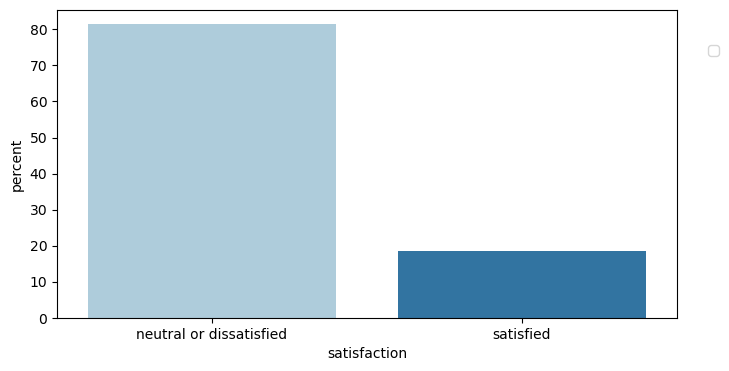

```python
plt.figure(figsize=(8,4))
sns.countplot(data=df[df['Class']=='Eco'],x='satisfaction', hue ='satisfaction', palette= 'Paired', stat='percent')
plt.legend(loc=(1.05,.85))
```

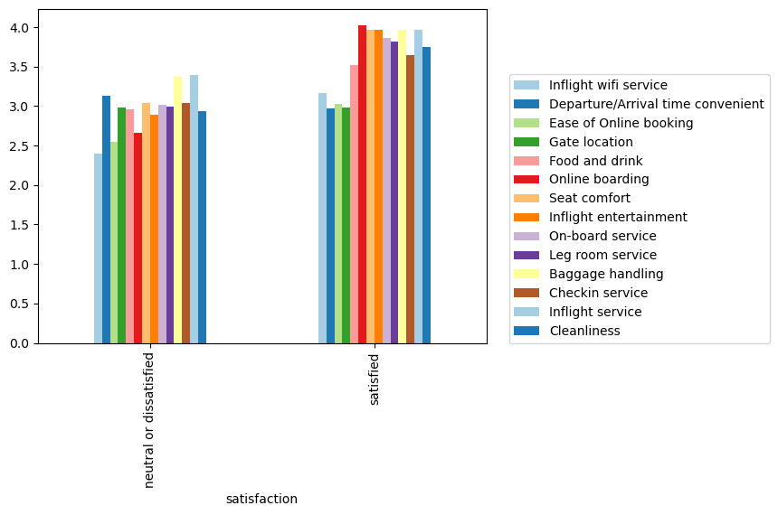

```python
sns.set_palette('Paired')
df_eco=df[df['Class']==('Eco' and 'Eco Plus')]
df.groupby('satisfaction')[['Inflight wifi service',
       'Departure/Arrival time convenient', 'Ease of Online booking',
       'Gate location', 'Food and drink', 'Online boarding', 'Seat comfort',
       'Inflight entertainment', 'On-board service', 'Leg room service',
       'Baggage handling', 'Checkin service', 'Inflight service',
       'Cleanliness']].mean().plot(kind='bar')
plt.legend(loc=(1.05,0))
```

How do all metrics relate to one another? Is it consistent with what we found up to this point?

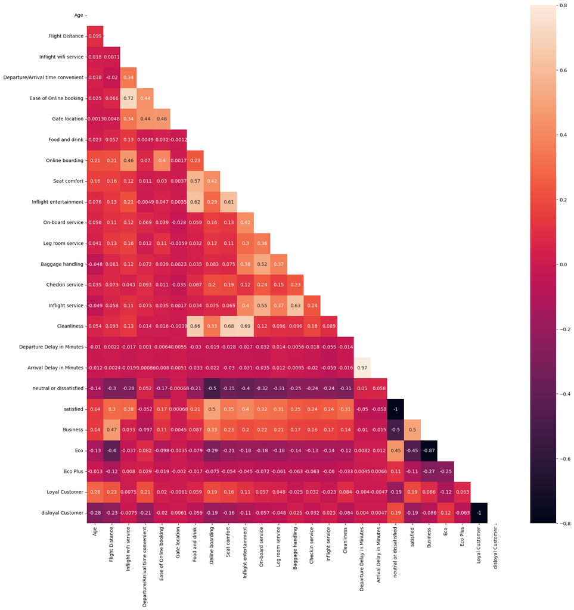

```python
#normalize data
df_num_norm=(df_num-df_num.mean())/df_num.std()
# Compute the correlation matrix
corr = df_num_norm.corr()
# Generate a mask for the upper triangle
mask = np.triu(np.ones_like(corr, dtype=bool))

plt.figure(figsize=(20,20))
sns.heatmap(corr, mask=mask,vmin=-.8,vmax=0.8,annot=True)
```

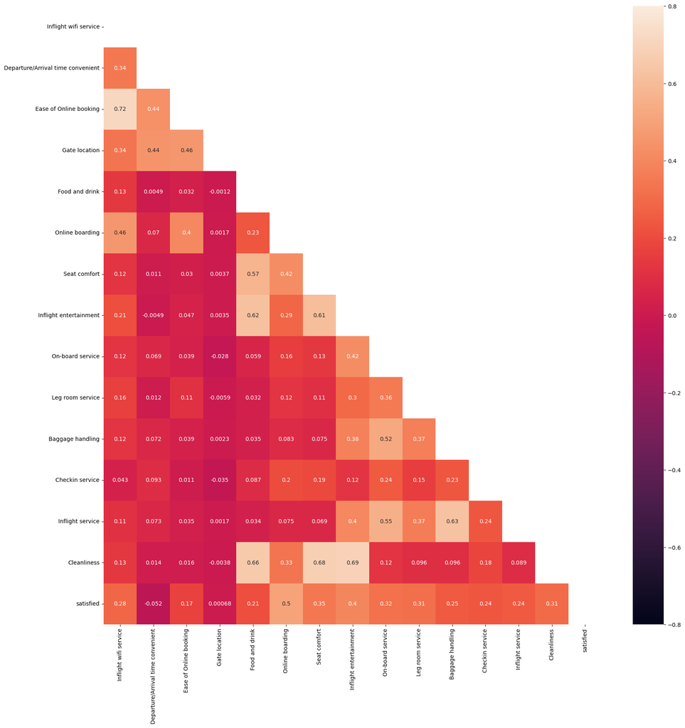

```python
#normalize data
df_ratings=df[['Inflight wifi service',
       'Departure/Arrival time convenient', 'Ease of Online booking',
       'Gate location', 'Food and drink', 'Online boarding', 'Seat comfort',
       'Inflight entertainment', 'On-board service', 'Leg room service',
       'Baggage handling', 'Checkin service', 'Inflight service',
       'Cleanliness', 'satisfied']]
df_rat_norm=(df_ratings-df_ratings.mean())/df_ratings.std()
# Compute the correlation matrix
corr = df_rat_norm.corr()
# Generate a mask for the upper triangle
mask = np.triu(np.ones_like(corr, dtype=bool))

plt.figure(figsize=(20,20))
sns.heatmap(corr, mask=mask,vmin=-.8,vmax=0.8,annot=True)
```

Online boarding and inflight entertainment have the strongest correlations to satisfaction.

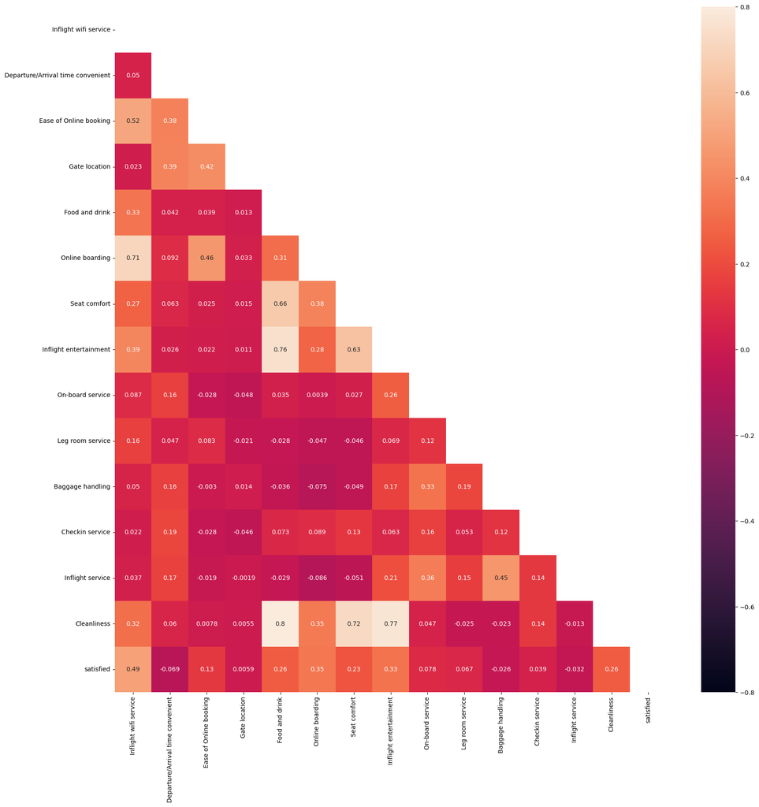

```python
#normalize data
df_eco_num=df_eco[['Inflight wifi service',
       'Departure/Arrival time convenient', 'Ease of Online booking',
       'Gate location', 'Food and drink', 'Online boarding', 'Seat comfort',
       'Inflight entertainment', 'On-board service', 'Leg room service',
       'Baggage handling', 'Checkin service', 'Inflight service',
       'Cleanliness', 'satisfied']]
df_eco_num_norm=(df_eco_num-df_eco_num.mean())/df_eco_num.std()
# Compute the correlation matrix
corr = df_eco_num_norm.corr()
# Generate a mask for the upper triangle
mask = np.triu(np.ones_like(corr, dtype=bool))

plt.figure(figsize=(20,20))
sns.heatmap(corr, mask=mask,vmin=-.8,vmax=0.8,annot=True)
```

Online boarding seems to be an important metric, how do the three classes rate it?

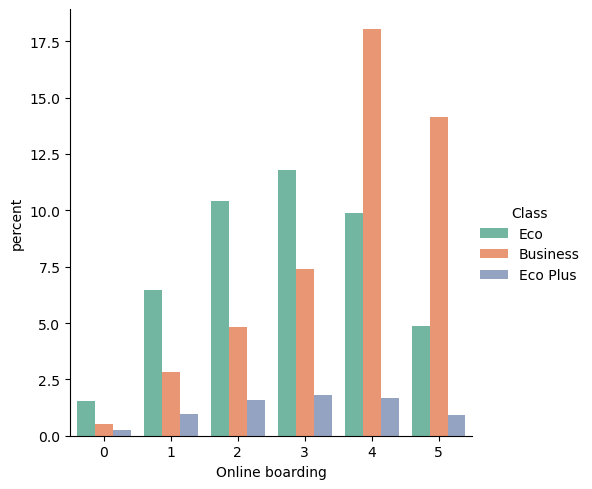

```python
sns.catplot(data=df, x='Online boarding', hue='Class', palette='Set2', kind="count", stat='percent')
```

how do delays in the flight affect satisfaction?

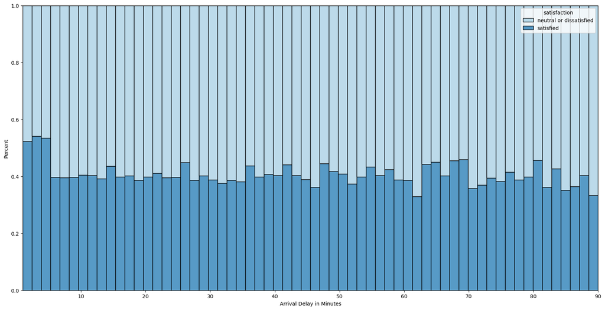

```python
plt.figure(figsize=(20,10))
sns.histplot(data=df, x='Arrival Delay in Minutes', hue='satisfaction',binrange=[1,90], multiple="fill", stat='percent')
```

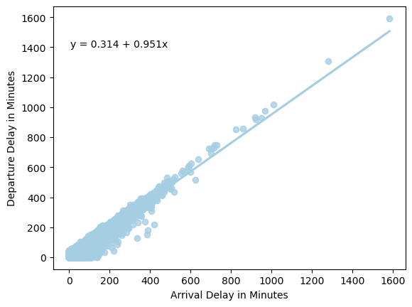

```python
import scipy
##create regplot
p = sns.regplot(data=df_num, x='Arrival Delay in Minutes', y='Departure Delay in Minutes')

#calculate slope and intercept of regression equation
slope, intercept, r, p, sterr = scipy.stats.linregress(x=p.get_lines()[0].get_xdata(),
                                                       y=p.get_lines()[0].get_ydata())

#add regression equation to plot
plt.text(5, 1400, 'y = ' + str(round(intercept,3)) + ' + ' + str(round(slope,3)) + 'x')
```

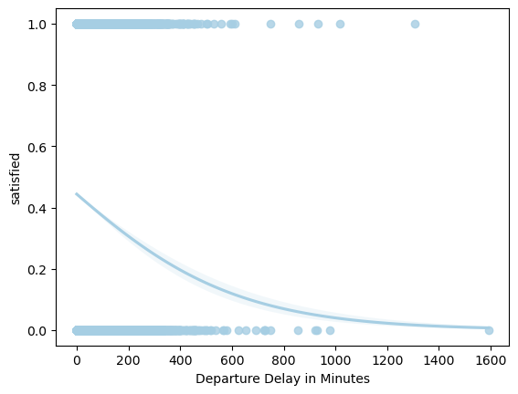

```python
sns.regplot(x=df['Departure Delay in Minutes'], y=df['satisfied'], logistic=True)
```

looks like passengers expect the flight to be on time, so flights with no delay have no effecton satisfaction, but the longer a flight is delayed, the more likely that passengers are dissatisfied

comparing the logistic regressions of the most important metrics that we found for each class

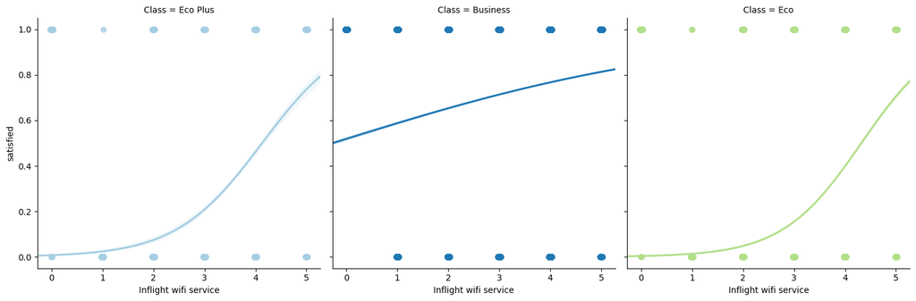

```python
sns.lmplot(x='Inflight wifi service', y="satisfied", col='Class', hue='Class', data=df, x_jitter=.02, logistic=True, truncate=False)
```

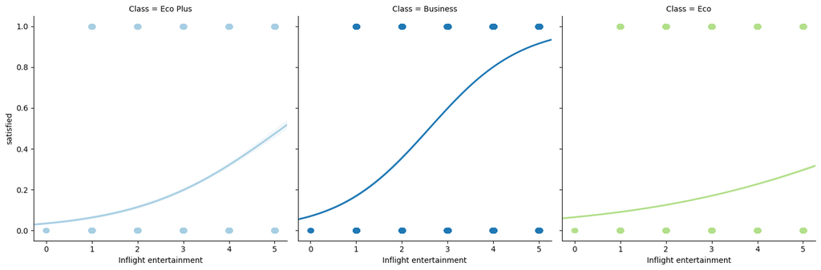

```python
sns.lmplot(x='Inflight entertainment', y="satisfied", col='Class', hue='Class', data=df, x_jitter=.02, logistic=True, truncate=False)
```

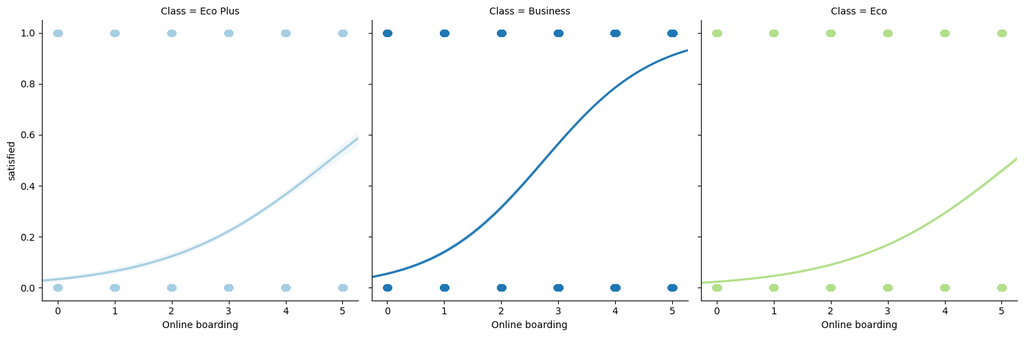

```python
g = sns.lmplot(x='Online boarding', y="satisfied", col='Class', hue='Class', data=df, x_jitter=.02, logistic=True, truncate=False)
```

Eco Plus Passengers are more likely to be satisfied when they rate the online boarding as a 5. Business class passengers are more likely to be satisfied if they rate the online boarding as a 3. Economy class passengers are unlikely to be satisfied even with an online boarding rating of 5

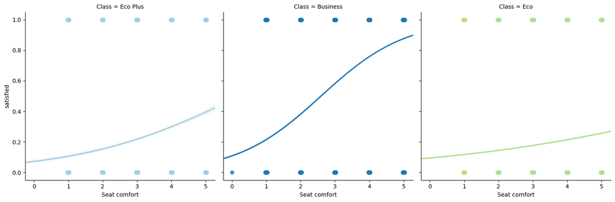

```python
g = sns.lmplot(x='Seat comfort', y="satisfied", col='Class', hue='Class', data=df, x_jitter=.02, logistic=True, truncate=False)
```